# TLC Data Analysis

Alex Powers

9/12/2018

### Setup

```r
setwd("~/Workdir/tlc/R")
library(bigrquery)
library(ggplot2)
library(tidyverse)
project = "sylvan-rampart-159916"
set_service_token("zuul.json")
sql <- "SELECT trip_distance, tip_amt, rand(5) AS rand FROM tlc.combo7
WHERE payment_type = 'CRD' AND trip_distance < 100
ORDER BY rand LIMIT 850000"
questX <- query_exec(sql, project = project, useLegacySql = FALSE, max_pages = Inf)
```

### Does trip distance increase tipping?

We’d expect to see that drivers tip more as rides get longer - is that the case?

```r
questXlm <- lm(tip_amt ~ trip_distance, data = questX)
summary(questXlm)
```

```
##
## Call:
## lm(formula = tip_amt ~ trip_distance, data = questX)
##
## Residuals:
##     Min      1Q  Median      3Q     Max
## -31.184  -0.477  -0.046   0.418 198.581
##
## Coefficients:
##                Estimate Std. Error t value Pr(>|t|)
## (Intercept)   0.9935039  0.0025265   393.2   <2e-16 ***
## trip_distance 0.4885214  0.0005367   910.2   <2e-16 ***
## ---
## Signif. codes:  0 '***' 0.001 '**' 0.01 '*' 0.05 '.' 0.1 ' ' 1
##
## Residual standard error: 1.734 on 849998 degrees of freedom
## Multiple R-squared:  0.4936, Adjusted R-squared:  0.4936
## F-statistic: 8.285e+05 on 1 and 849998 DF,  p-value: < 2.2e-16
```

We can see that there is a positive and strong effect of trip distance on tip amount to the point where trip distance explains roughly half the variability in tip amount.

Plotting these data reveals additional characteristics.

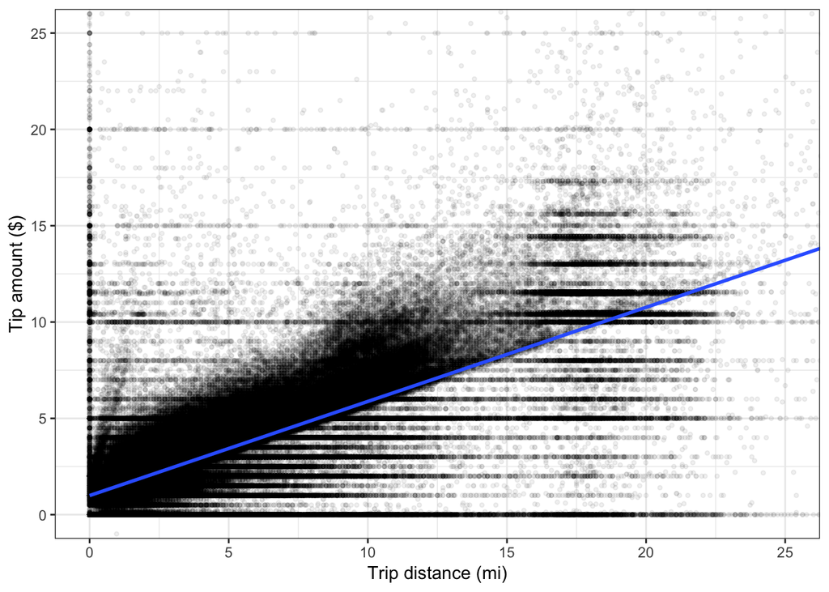

```r
ggplot(questX, aes(trip_distance, tip_amt)) +
  geom_point(shape = 20, alpha = 1/16) +
  geom_smooth(method = lm) +
  coord_cartesian(xlim = c(0, 25), ylim = c(0, 25)) +
  theme_bw() +
  labs(x = "Trip distance (mi)", y = "Tip amount ($)")
```

### Does trip distance increase tipping generosity?

It’s fairly unsurprising that increased trip distance leads to larger trips. But do riders respond by rewarding drivers for long-distance hauls, or does sticker shock make them less likely to leave generous tips?

First we yank down some data on total fare as well as tip paid.

```r
sql2 <- "SELECT trip_distance, tip_amt, total_amt, passenger_count, rand(5) AS rand FROM tlc.combo7
WHERE payment_type = 'CRD' AND trip_distance < 100
ORDER BY rand LIMIT 850000"
questY <- query_exec(sql2, project = project, useLegacySql = FALSE, max_pages = Inf)
```

```
## 6.0 gigabytes processed
```

Next step is to calculate a tip share variable and run a regression with that as the outcome.

```r
library(dplyr)
questYA <- questY %>%
  mutate(tip_share = tip_amt/total_amt) %>% select(-rand)

questYAlm <- lm(tip_share ~ trip_distance, data = questYA)
summary(questYAlm)
```

```
##
## Call:
## lm(formula = tip_share ~ trip_distance, data = questYA)
##
## Residuals:
##      Min       1Q   Median       3Q      Max
## -0.15335 -0.02449  0.01133  0.01812  0.84561
##
## Coefficients:
##                 Estimate Std. Error t value Pr(>|t|)
## (Intercept)    1.533e-01  7.564e-05 2027.39   <2e-16 ***
## trip_distance -1.044e-03  1.607e-05  -64.94   <2e-16 ***
## ---
## Signif. codes:  0 '***' 0.001 '**' 0.01 '*' 0.05 '.' 0.1 ' ' 1
##
## Residual standard error: 0.0519 on 849995 degrees of freedom
##   (3 observations deleted due to missingness)
## Multiple R-squared:  0.004938,   Adjusted R-squared:  0.004936
## F-statistic:  4218 on 1 and 849995 DF,  p-value: < 2.2e-16
```

Now we see a slight, but statistically significant, *negative* relationship. People become slightly less generous as the meter climbs.

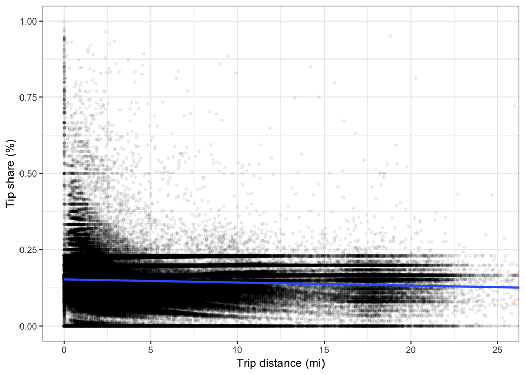

```r
ggplot(questYA, aes(trip_distance, tip_share)) +
  geom_point(shape = 20, alpha = 1/16) +
  geom_smooth(method = lm) +
  coord_cartesian(xlim = c(0, 25), ylim = c(0, 1)) +
  theme_bw() +
  labs(x = "Trip distance (mi)", y = "Tip share (%)")
```

It’s a bit difficult to parse the trends in this scatter - not as clear as the last one. Let’s take a different approach, by splitting the dataset into four sections by ride length and eyeball any differences in the distributions.

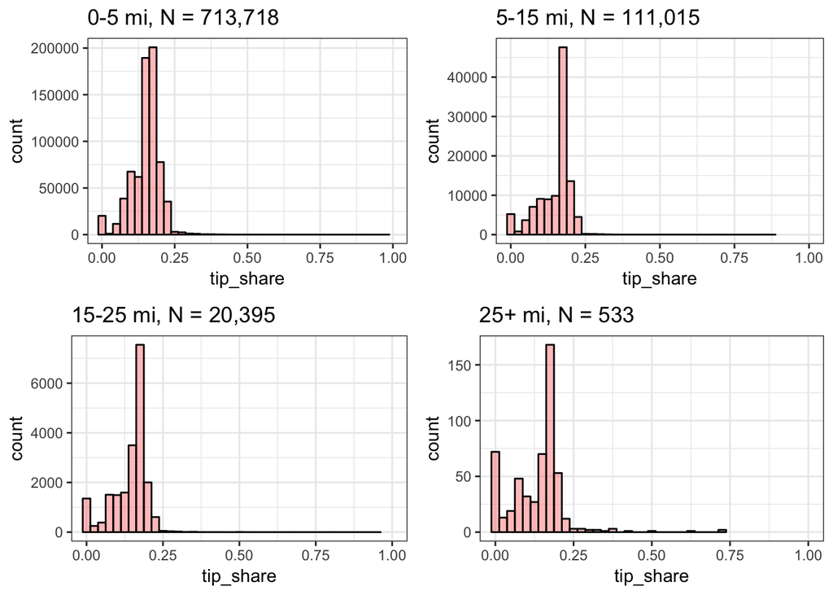

```r
questY1 <- questYA %>% filter(trip_distance > 0 & trip_distance <= 5) %>%
  select(trip_distance, passenger_count, tip_share)
questY2 <- questYA %>% filter(trip_distance > 5 & trip_distance <= 15) %>%
  select(trip_distance, passenger_count, tip_share)
questY3 <- questYA %>% filter(trip_distance > 15 & trip_distance <= 25) %>%
  select(trip_distance, passenger_count, tip_share)
questY4 <- questYA %>% filter(trip_distance > 25) %>%
  select(trip_distance, passenger_count, tip_share)

q1 <-ggplot(questY1, aes(tip_share)) +
  geom_histogram(color="black", alpha = .4, fill="#FF6666", binwidth = .025) +
  coord_cartesian(xlim = c(0, 1)) +
  theme_bw() +
  coord_cartesian(xlim = c(0, 1)) +
  labs(title = "0-5 mi, N = 713,718")
q2 <-ggplot(questY2, aes(tip_share)) +
  geom_histogram(color="black", alpha = .4, fill="#FF6666", binwidth = .025) +
  coord_cartesian(xlim = c(0, 1)) +
  theme_bw() +
  labs(title = "5-15 mi, N = 111,015")
q3 <-ggplot(questY3, aes(tip_share)) +
  geom_histogram(color="black", alpha = .4, fill="#FF6666", binwidth = .025) +
  coord_cartesian(xlim = c(0, 1)) +
  theme_bw() +
  labs(title = "15-25 mi, N = 20,395")
q4 <-ggplot(questY4, aes(tip_share)) +
  geom_histogram(color="black", alpha = .4, fill="#FF6666", binwidth = .025) +
  coord_cartesian(xlim = c(0, 1)) +
  theme_bw() +
  labs(title = "25+ mi, N = 533")

library(gridExtra)
grid.arrange(q1, q2, q3, q4, nrow = 2)
```

The share of people dispensing little to no tip increaess dramatically in the bucket of rides over 25 miles. You also see that nobody’s tipped over 75% of the trip - not so for the other 3 tranches.

### What other factors influence tipping behavior?

Let’s check the usual suspects by running a multiple linear regression on all plausibly linked variables:

```r
sql3 <- "SELECT trip_distance, tip_amt, total_amt, pickup_datetime, passenger_count, trip_time_in_secs, mta_tax, surcharge, tolls_amt, vendor_id, rand(5) AS rand FROM tlc.combo7
WHERE payment_type = 'CRD' AND trip_distance < 100
ORDER BY rand LIMIT 850000"

questZ <- query_exec(sql3, project = project, useLegacySql = FALSE, max_pages = Inf)
```

```
## 13.2 gigabytes processed
```

```r
questZlm <- lm (tip_amt/total_amt ~ trip_distance + pickup_datetime + passenger_count +
               trip_time_in_secs + mta_tax + surcharge + tolls_amt + vendor_id, data = questZ)
```

```r
summary (questZlm)
```

```
##
## Call:
## lm(formula = tip_amt/total_amt ~ trip_distance + pickup_datetime +
##     passenger_count + trip_time_in_secs + mta_tax + surcharge +
##     tolls_amt + vendor_id, data = questZ)
##
## Residuals:
##      Min       1Q   Median       3Q      Max
## -0.28584 -0.02375  0.01116  0.01811  0.87485
##
## Coefficients:
##                     Estimate Std. Error t value Pr(>|t|)
## (Intercept)        1.017e-01  8.504e-03  11.960  < 2e-16 ***
## trip_distance     -1.350e-03  2.017e-05 -66.920  < 2e-16 ***
## pickup_datetime    1.624e-11  6.167e-12   2.634  0.00845 **
## passenger_count    5.857e-05  4.335e-05   1.351  0.17668
## trip_time_in_secs -1.009e-09  3.641e-09  -0.277  0.78173
## mta_tax            6.688e-02  1.643e-03  40.706  < 2e-16 ***
## surcharge         -2.472e-03  1.567e-04 -15.776  < 2e-16 ***
## tolls_amt          1.680e-03  5.492e-05  30.581  < 2e-16 ***
## vendor_idVTS      -5.513e-03  1.188e-04 -46.397  < 2e-16 ***
## ---
## Signif. codes:  0 '***' 0.001 '**' 0.01 '*' 0.05 '.' 0.1 ' ' 1
##
## Residual standard error: 0.05176 on 849988 degrees of freedom
##   (3 observations deleted due to missingness)
## Multiple R-squared:  0.01036,    Adjusted R-squared:  0.01035
## F-statistic:  1113 on 8 and 849988 DF,  p-value: < 2.2e-16
```

And let’s get standardized coefficients so we can compare variable effects easily.

```r
library(MASS)
library(QuantPsyc)
lm.beta(questZlm)
```

```
##     trip_distance   pickup_datetime   passenger_count trip_time_in_secs
##     -0.0908842961      0.0028422350      0.0015425867     -0.0002990972
##           mta_tax         surcharge         tolls_amt      vendor_idVTS
##      0.0459308268     -0.0170897342      0.0430194858                NA
```

#### Does weather influence tipping?

What about the weather? Taxis become scarce (and Uber prices surge) during rain squalls - but can weather’s effect on tipping behavior be detected in the data we have at hand?

Using Weather Underground’s entire 2013 records from the Central Park station, I found that the 9 days with both rain and snow saw a statistically significant increase in tips as a share of the total fare for those days – albeit a small one, of 0.2 percentage points. Neither rain nor snow, in isolation, has a significant effect. The boxplot below illustrates this neatly.

```r
weather <- read.csv("unified-weather-labels.csv", header = TRUE)
w1lm <- lm (tip_share ~ events, data = weather)
summary(w1lm)
```

```
##
## Call:
## lm(formula = tip_share ~ events, data = weather)
##
## Residuals:
##     Min      1Q  Median      3Q     Max
## -0.6019 -0.1246  0.0259  0.1091  0.6646
##
## Coefficients:
##                    Estimate Std. Error  t value Pr(>|t|)
## (Intercept)       14.996268   0.010136 1479.560  < 2e-16 ***
## eventsRain        -0.004881   0.018415   -0.265    0.791
## eventsRain & Snow  0.235137   0.052990    4.437 1.21e-05 ***
## eventsSnow         0.022960   0.040304    0.570    0.569
## ---
## Signif. codes:  0 '***' 0.001 '**' 0.01 '*' 0.05 '.' 0.1 ' ' 1
##
## Residual standard error: 0.156 on 361 degrees of freedom
## Multiple R-squared:  0.0536, Adjusted R-squared:  0.04573
## F-statistic: 6.815 on 3 and 361 DF,  p-value: 0.0001769
```

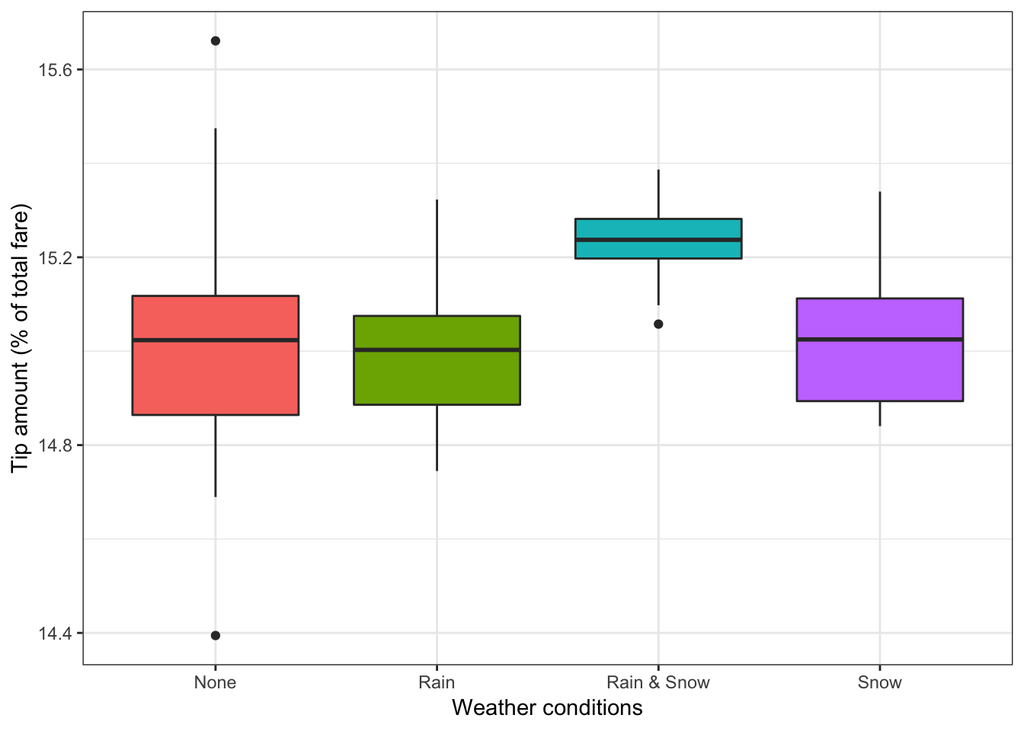

```r
ggplot(weather, aes(events, tip_share)) +
  geom_boxplot(aes(fill=events)) +
  theme_bw() +
  labs(x = "Weather conditions", y = "Tip amount (% of total fare)") +
  guides(fill = FALSE)
```

What about temperature?

```r
w2lm <- lm (tip_share ~ avg_temp, data = weather)
summary(w2lm)
```

```
##
## Call:
## lm(formula = tip_share ~ avg_temp, data = weather)
##
## Residuals:
##      Min       1Q   Median       3Q      Max
## -0.53982 -0.12313  0.02283  0.11346  0.53954
##
## Coefficients:
##               Estimate Std. Error t value Pr(>|t|)
## (Intercept) 15.2188013  0.0253403 600.578   <2e-16 ***
## avg_temp    -0.0038983  0.0004342  -8.978   <2e-16 ***
## ---
## Signif. codes:  0 '***' 0.001 '**' 0.01 '*' 0.05 '.' 0.1 ' ' 1
##
## Residual standard error: 0.1447 on 363 degrees of freedom
## Multiple R-squared:  0.1817, Adjusted R-squared:  0.1794
## F-statistic:  80.6 on 1 and 363 DF,  p-value: < 2.2e-16
```

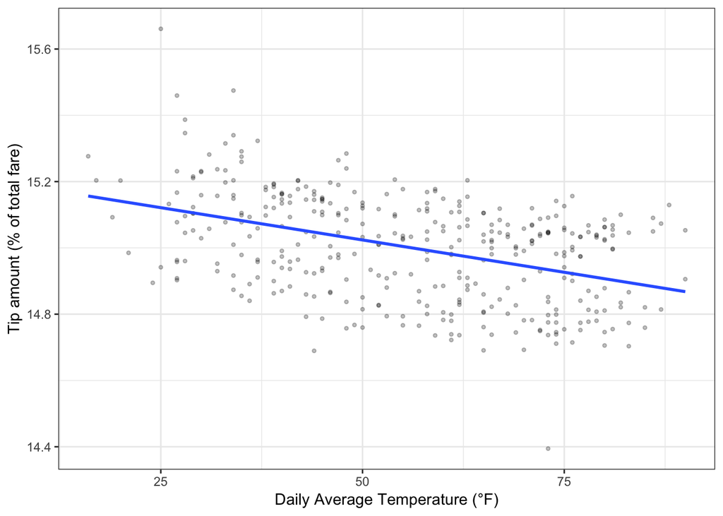

```r
ggplot(weather, aes(avg_temp, tip_share)) +
  geom_point(shape = 20, alpha = 1/4) +
  geom_smooth(method = lm, se=FALSE) +
  theme_bw() +
  labs(x = "Daily Average Temperature (°F)", y = "Tip amount (% of total fare)")
```

Temperature also has a statistically significant effect on tipping; a one-degree decrease in temperature results in a 0.004 percentage point increase in tip. The distribution in the scatter plot is fairly apparent as well.